# Exp2_pilotdata

Mrudula

22/10/2020

This is the Pilot Data Analysis collected from Prolific and Hiwis for the second version of the Experiment that brought back the distractor words towards the center and the number appears either at the top or bottom.

The design looks like this.

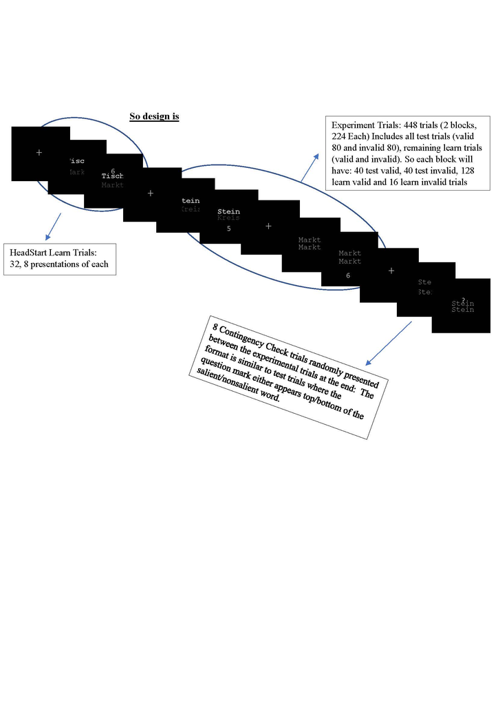

Design of the experiment.

Loading the libraries and the relevant data files

2. Checking balance in design and all trials and conditions are balanced.

Cleaning data : removing unnecessaary columns, filling Screen background and block count to every cell, splitting the RT column and changed the units to ms and creating a column for Error Rate

### Demographics

Participants’ Age and Gender

Mean Age of participants

| Min. | 1st Qu. | Median | Mean | 3rd Qu. | Max. |
| --- | --- | --- | --- | --- | --- |
| 22 | 25.5 | 27.5 | 27.38 | 29.5 | 32 |

Gender distribution

| Var1 | Freq |
| --- | --- |
| female | 3 |
| male | 5 |

Summary of the overall RT

Mean RT

| Min. | 1st Qu. | Median | Mean | 3rd Qu. | Max. |
| --- | --- | --- | --- | --- | --- |
| 329.7 | 505 | 568 | 602.7 | 640 | 10456 |

Accuracy

| 0 | 1 |
| --- | --- |
| 214 | 3626 |

### Exclusion of Outliers and Farouts

Removing outliers and farouts and showing the summary of RTs for each exclusion criteria

Summary of RT after removing Farouts

| Min. | 1st Qu. | Median | Mean | 3rd Qu. | Max. | NA’s |
| --- | --- | --- | --- | --- | --- | --- |
| 329.7 | 506 | 567 | 580.1 | 634.8 | 1202 | 297 |

Summary of RT after removing Outliers

| Min. | 1st Qu. | Median | Mean | 3rd Qu. | Max. | NA’s |
| --- | --- | --- | --- | --- | --- | --- |
| 329.7 | 501.9 | 564 | 568.6 | 626.4 | 932.6 | 414 |

## Analysis of Validity across all trials

There is a strong interaction between validity and condition, where test valid trials are faster and learn valid trials are slower

- **ANOVA**:

  | Effect | DFn | DFd | SSn | SSd | F | p | p<.05 | ges |
  | --- | --- | --- | --- | --- | --- | --- | --- | --- |
  | (Intercept) | 1 | 7 | 10699644 | 51755 | 1447 | 2.257e-09 | * | 0.9949 |
  | Validity | 1 | 7 | 20.09 | 592.4 | 0.2374 | 0.641 |  | 0.0003683 |
  | Condition | 1 | 7 | 0.1627 | 1874 | 0.0006076 | 0.981 |  | 2.984e-06 |
  | Validity:Condition | 1 | 7 | 374.7 | 299.7 | 8.754 | 0.02115 | * | 0.006826 |

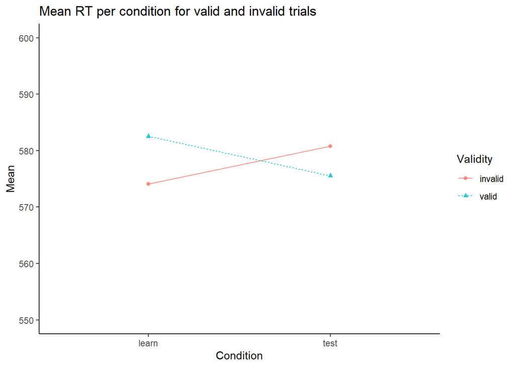

Splitting the data as learn and test trials to analyze individually

```r
Exp2learn_Pilot <- Exp2_Pilot %>%
  filter(Condition == "learn")

Exp2test_Pilot <- Exp2_Pilot %>%
  filter(Condition == "test")

Exp2learn_Pilot<- Exp2learn_Pilot%>%
  mutate(PositionMatch = ifelse(as.character(PositionD)==as.character(PositionT),"same","different"))
```

## Analysis for learn trials

#### 1. Farouts

A t test to determine the difference between valid and invalid trials showeed a p value of .13 in the direction of valid trials slower than invalid.

Paired t-test: `RT_ifo` by `Validity`

| Test statistic | df | P value | Alternative hypothesis | mean of the differences |
| --- | --- | --- | --- | --- |
| -1.693 | 7 | 0.1344 | two.sided | -8.429 |

Plot showing the validity effect per participant in learn trials

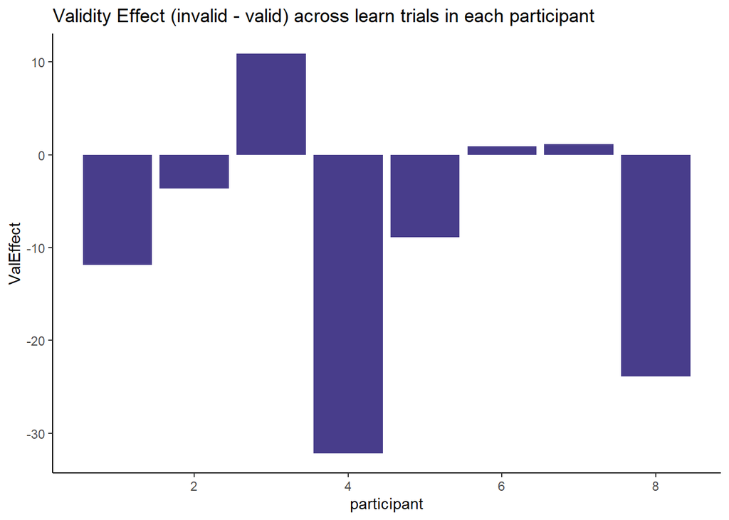

#### 2. Outliers

T test revealed a p value of .09 for learn valid and invalid trials again in the same direction as the farouts where invalid trials are faster than valid

[output not shown]

#### 3. Error Rate

There is a significant difference between error rates of valid and invalid trials in learn condition wherein the invalid trials are more accurate than valid trials

t test results for error Rates

| Test statistic | df | P value | Alternative hypothesis | mean of the differences |
| --- | --- | --- | --- | --- |
| -5.4 | 7 | 0.001009 * * | two.sided | -0.01997 |

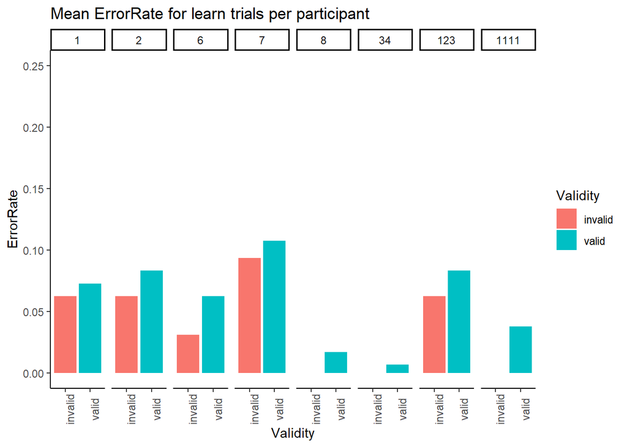

## Analysis of Test Trials

#### 1. Farouts

We have an almost significant effect of Validity and a significant interaction of Saliency x Validity. The plot also shows that it is in the expected direction

- **ANOVA**:

  | Effect | DFn | DFd | SSn | SSd | F | p | p<.05 | ges |
  | --- | --- | --- | --- | --- | --- | --- | --- | --- |
  | (Intercept) | 1 | 7 | 10698287 | 55791 | 1342 | 2.933e-09 | * | 0.9946 |
  | Saliency | 1 | 7 | 91.83 | 1144 | 0.562 | 0.4779 |  | 0.001588 |
  | Validity | 1 | 7 | 207.1 | 389.6 | 3.721 | 0.09506 |  | 0.003574 |
  | Saliency:Validity | 1 | 7 | 403.2 | 420.2 | 6.716 | 0.03586 | * | 0.006934 |

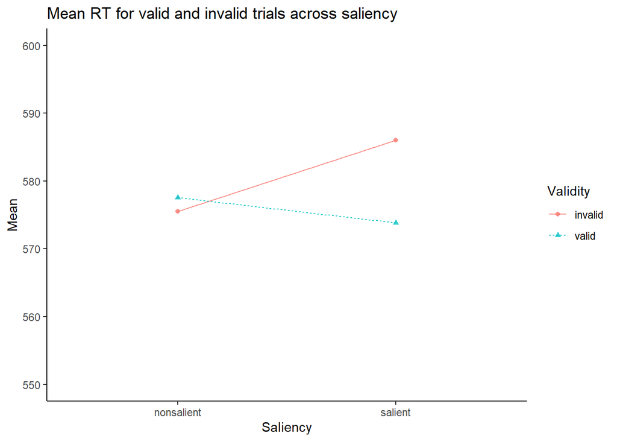

Plot showing the Validity effect across participants

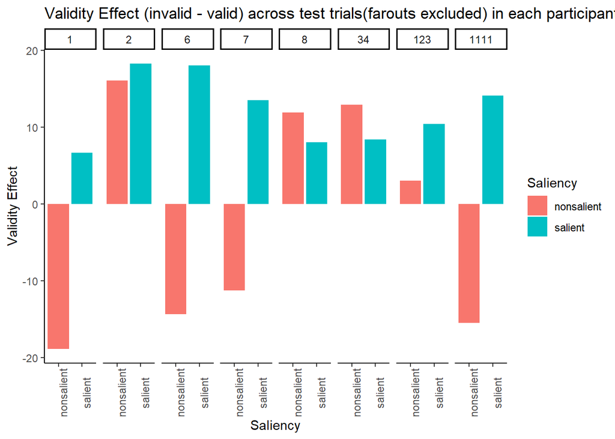

#### 2. Outliers

It does not appear significant anymore but the plot seems like smaller/weaker version of the farouts

- **ANOVA**:

  | Effect | DFn | DFd | SSn | SSd | F | p | p<.05 | ges |
  | --- | --- | --- | --- | --- | --- | --- | --- | --- |
  | (Intercept) | 1 | 7 | 10359272 | 51291 | 1414 | 2.448e-09 | * | 0.9948 |
  | Saliency | 1 | 7 | 230.5 | 1575 | 1.024 | 0.3452 |  | 0.004242 |
  | Validity | 1 | 7 | 17.01 | 639.5 | 0.1862 | 0.6791 |  | 0.0003143 |
  | Saliency:Validity | 1 | 7 | 58 | 604.9 | 0.6712 | 0.4396 |  | 0.001071 |

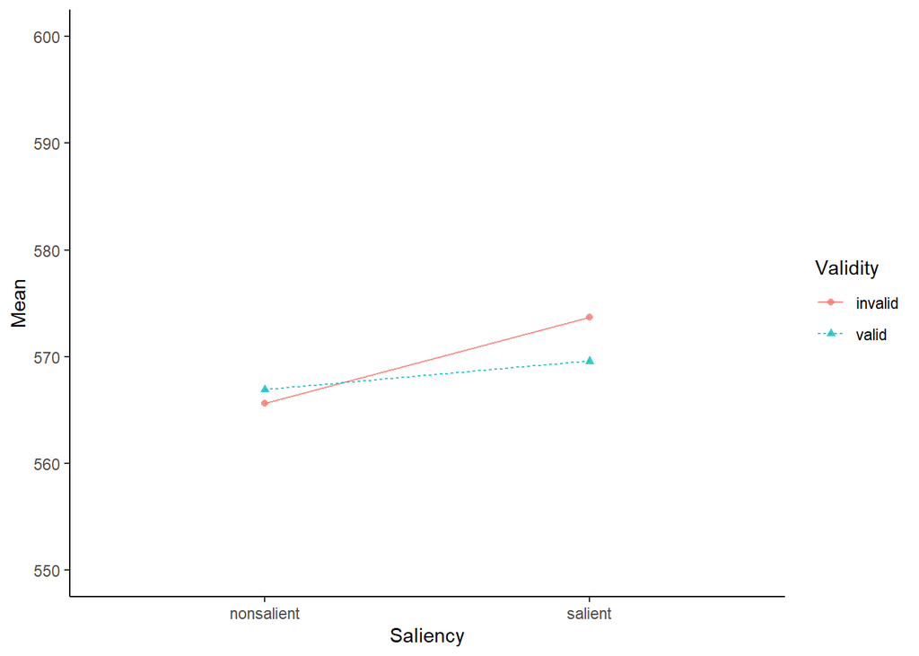

Effect across each participant

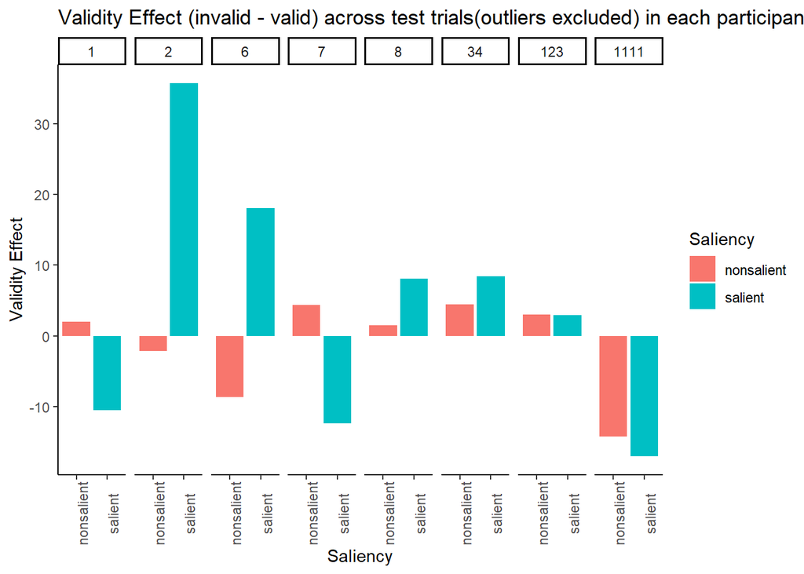

### 3. Error Rate

There seems to be an almost significant effect of saliency and validity

- **ANOVA**:

  | Effect | DFn | DFd | SSn | SSd | F | p | p<.05 | ges |
  | --- | --- | --- | --- | --- | --- | --- | --- | --- |
  | (Intercept) | 1 | 7 | 0.09031 | 0.01844 | 34.29 | 0.000627 | * | 0.741 |
  | Saliency | 1 | 7 | 0.00125 | 0.001875 | 4.667 | 0.06758 |  | 0.0381 |
  | Validity | 1 | 7 | 0.002812 | 0.005312 | 3.706 | 0.09561 |  | 0.08182 |
  | Saliency:Validity | 1 | 7 | 0.0003125 | 0.005938 | 0.3684 | 0.563 |  | 0.009804 |

[figure not shown]

## Exploratory: Adding the factor of Position

This analysis discusses the effect of salient word and the position of the number. Position Match variable indicates whether the salient word position and number appeared in the same place or not. Although this may not be of help because we brought the words closer together, I added this factor anyway to see how the data is.

## Analysis of learn trials - Position

#### 1. Farouts

Here, we would have expected the pattern to be reversed, where valid and same position trials are fastest. The validity effect is at p = .12

- **ANOVA**:

  | Effect | DFn | DFd | SSn | SSd | F | p | p<.05 | ges |
  | --- | --- | --- | --- | --- | --- | --- | --- | --- |
  | (Intercept) | 1 | 7 | 10699509 | 51769 | 1447 | 2.259e-09 | * | 0.9947 |
  | Validity | 1 | 7 | 569.5 | 1297 | 3.073 | 0.1231 |  | 0.00993 |
  | PositionMatch | 1 | 7 | 267.6 | 1581 | 1.185 | 0.3125 |  | 0.004691 |
  | Validity:PositionMatch | 1 | 7 | 5.681 | 2130 | 0.01867 | 0.8952 |  | 1e-04 |

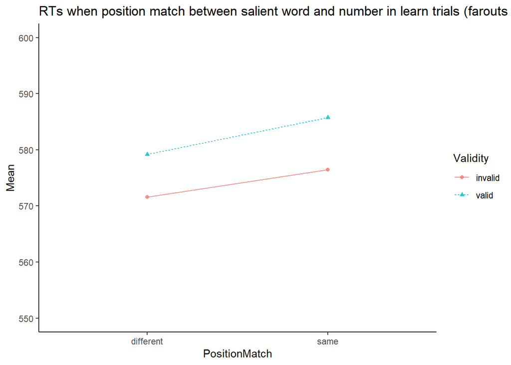

### 2. Outliers

Almost significant validity effect(p = .08) when PositionMatch of salient word and number is factored in the ANOVA

- **ANOVA**:

  | Effect | DFn | DFd | SSn | SSd | F | p | p<.05 | ges |
  | --- | --- | --- | --- | --- | --- | --- | --- | --- |
  | (Intercept) | 1 | 7 | 10259418 | 50692 | 1417 | 2.43e-09 | * | 0.9947 |
  | Validity | 1 | 7 | 393.6 | 686.3 | 4.015 | 0.08515 |  | 0.007176 |
  | PositionMatch | 1 | 7 | 7.74 | 1305 | 0.04152 | 0.8443 |  | 0.0001421 |
  | Validity:PositionMatch | 1 | 7 | 73.51 | 1776 | 0.2897 | 0.6071 |  | 0.001348 |

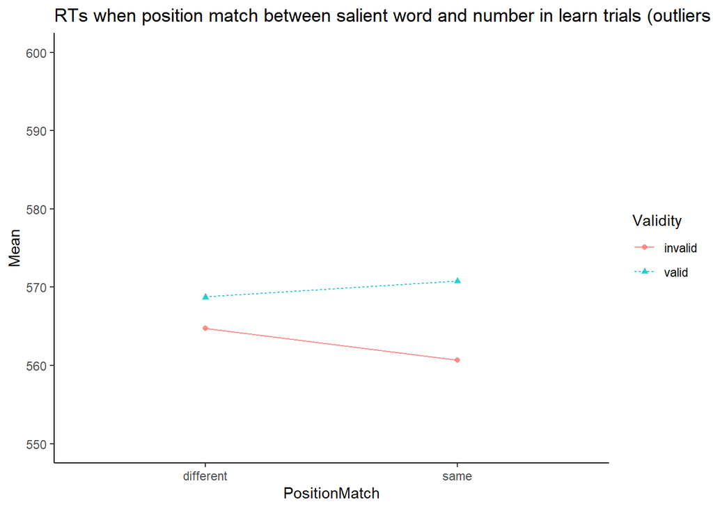

### 3. Error Rate

There is a strong validity effect. Valid trials have more errors than the invalid

- **ANOVA**:

  | Effect | DFn | DFd | SSn | SSd | F | p | p<.05 | ges |
  | --- | --- | --- | --- | --- | --- | --- | --- | --- |
  | (Intercept) | 1 | 7 | 0.07697 | 0.03505 | 15.37 | 0.005745 | * | 0.6197 |
  | Validity | 1 | 7 | 0.003189 | 0.0007656 | 29.16 | 0.001009 | * | 0.06324 |
  | PositionMatch | 1 | 7 | 0.0001507 | 0.00636 | 0.1659 | 0.696 |  | 0.00318 |
  | Validity:PositionMatch | 1 | 7 | 0.001019 | 0.005058 | 1.41 | 0.2738 |  | 0.02111 |

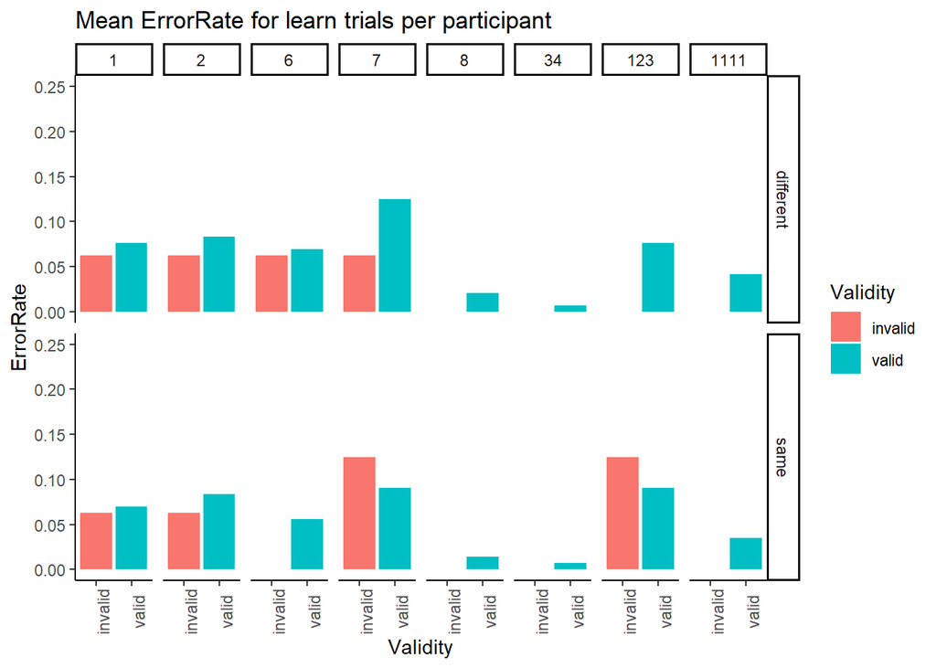

## Analysis of test trials - Position

### 1. Farouts

- **ANOVA**:

  | Effect | DFn | DFd | SSn | SSd | F | p | p<.05 | ges |
  | --- | --- | --- | --- | --- | --- | --- | --- | --- |
  | (Intercept) | 1 | 7 | 21382580 | 112045 | 1336 | 2.982e-09 | * | 0.9936 |
  | Validity | 1 | 7 | 452.7 | 797.8 | 3.972 | 0.08651 |  | 0.003267 |
  | PositionT | 1 | 7 | 150.5 | 7074 | 0.1489 | 0.711 |  | 0.001088 |
  | Saliency | 1 | 7 | 140.6 | 2261 | 0.4354 | 0.5305 |  | 0.001017 |
  | Validity:PositionT | 1 | 7 | 449.2 | 4259 | 0.7382 | 0.4187 |  | 0.003241 |
  | Validity:Saliency | 1 | 7 | 878.9 | 954.8 | 6.444 | 0.03875 | * | 0.006322 |
  | PositionT:Saliency | 1 | 7 | 66.03 | 9673 | 0.04778 | 0.8332 |  | 0.0004778 |
  | Validity:PositionT:Saliency | 1 | 7 | 0.8389 | 1069 | 0.005492 | 0.943 |  | 6.073e-06 |

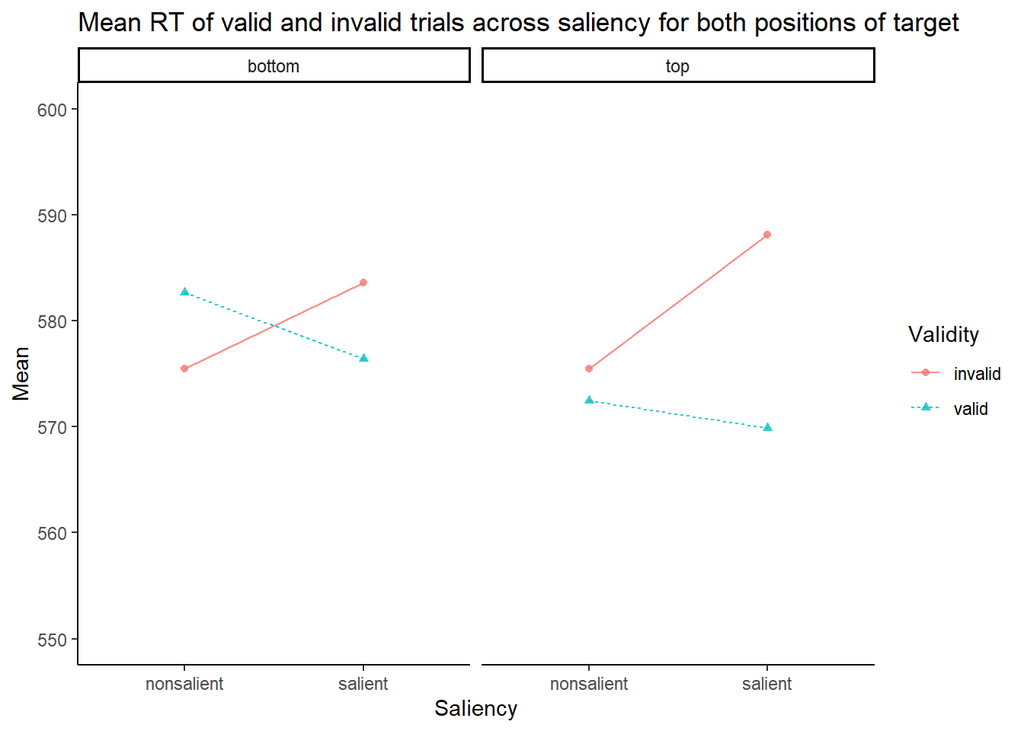

### 2. Outliers

No effect of Position of Target and validity or Saliency

- **ANOVA**:

  | Effect | DFn | DFd | SSn | SSd | F | p | p<.05 | ges |
  | --- | --- | --- | --- | --- | --- | --- | --- | --- |
  | (Intercept) | 1 | 7 | 20716402 | 102521 | 1414 | 2.444e-09 | * | 0.9942 |
  | Validity | 1 | 7 | 30.62 | 1213 | 0.1767 | 0.6868 |  | 0.0002514 |
  | PositionT | 1 | 7 | 35.96 | 4942 | 0.05093 | 0.8279 |  | 0.0002952 |
  | Saliency | 1 | 7 | 375.1 | 3117 | 0.8423 | 0.3893 |  | 0.003071 |
  | Validity:PositionT | 1 | 7 | 302.3 | 2569 | 0.8239 | 0.3942 |  | 0.002477 |
  | Validity:Saliency | 1 | 7 | 139.7 | 1168 | 0.8375 | 0.3906 |  | 0.001146 |
  | PositionT:Saliency | 1 | 7 | 6.974 | 5507 | 0.008864 | 0.9276 |  | 5.727e-05 |
  | Validity:PositionT:Saliency | 1 | 7 | 187 | 731.8 | 1.788 | 0.2229 |  | 0.001533 |

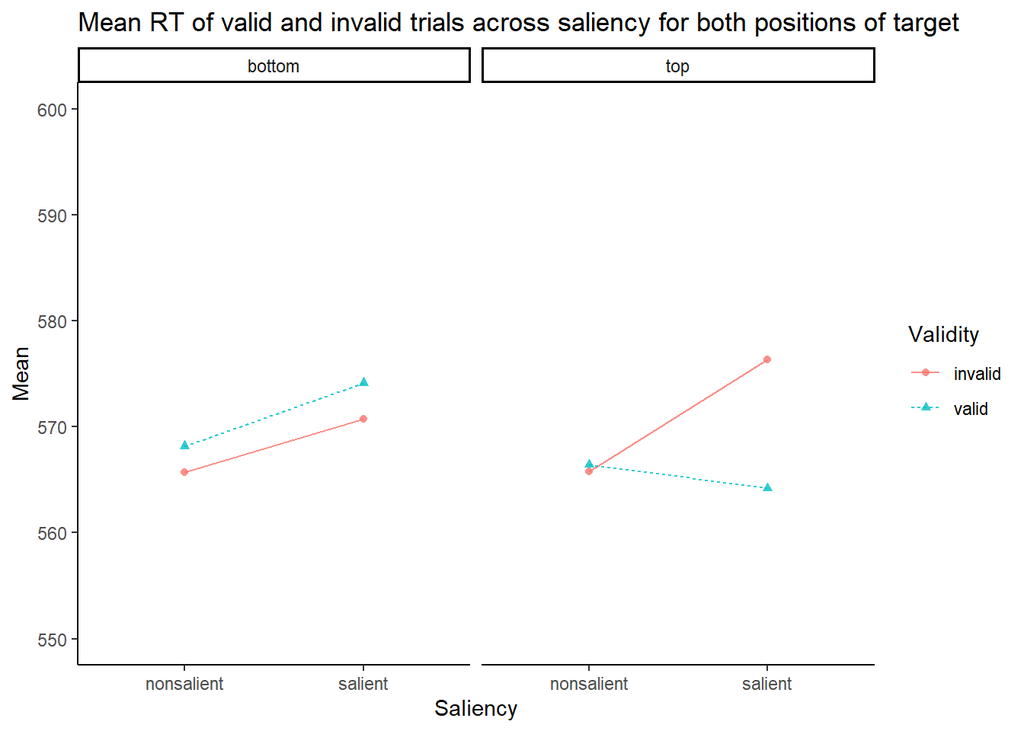

### 3. Error Rate

Almost significant effects of validity and saliency and the interaction between validity and Position of Target

- **ANOVA**:

  | Effect | DFn | DFd | SSn | SSd | F | p | p<.05 | ges |
  | --- | --- | --- | --- | --- | --- | --- | --- | --- |
  | (Intercept) | 1 | 7 | 0.1806 | 0.03687 | 34.29 | 0.000627 | * | 0.6437 |
  | Validity | 1 | 7 | 0.005625 | 0.01062 | 3.706 | 0.09561 |  | 0.05325 |
  | PositionT | 1 | 7 | 0.0001563 | 0.007344 | 0.1489 | 0.711 |  | 0.00156 |
  | Saliency | 1 | 7 | 0.0025 | 0.00375 | 4.667 | 0.06758 |  | 0.02439 |
  | Validity:PositionT | 1 | 7 | 0.003906 | 0.007344 | 3.723 | 0.09498 |  | 0.03759 |
  | Validity:Saliency | 1 | 7 | 0.000625 | 0.01188 | 0.3684 | 0.563 |  | 0.006211 |
  | PositionT:Saliency | 1 | 7 | 0.0001563 | 0.008594 | 0.1273 | 0.7318 |  | 0.00156 |
  | Validity:PositionT:Saliency | 1 | 7 | 0.001406 | 0.01359 | 0.7241 | 0.4229 |  | 0.01387 |

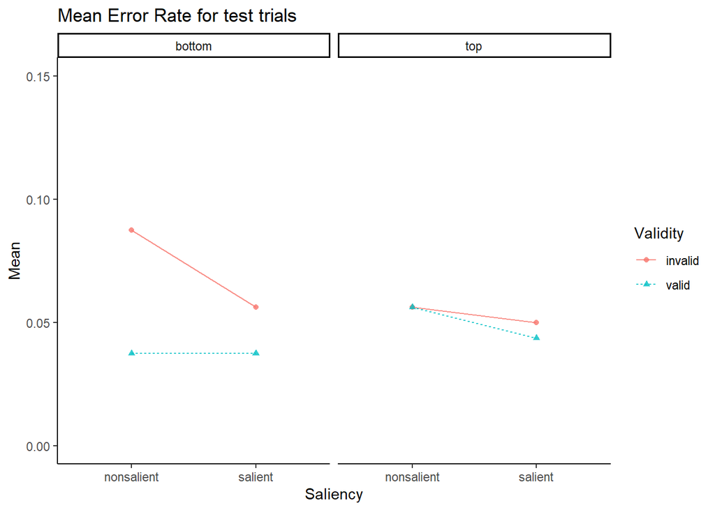